# W5D1_homework_kirsty

# MVP

## Part 1

#### Q1:

#### Take the data in the dataset qb_revenue_breakdown and make a stacked bar chart showing the sources of revenue across the two years in the dataset.

A:

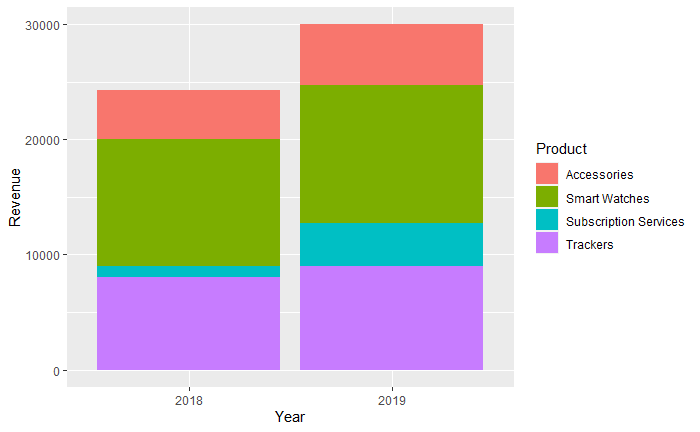

```r
revenue_breakdown %>%
  ggplot() +
  geom_bar(aes(x = Year, y = Revenue, fill = Product), stat = "identity")
```

#### Q2:

#### Make a line chart showing monthly sales of the “flagship product” - the ‘KwikBit Unit 1’ - over the last year. This data is inside qb_monthly_sales, but you will need to use filter() or subset() (base R).

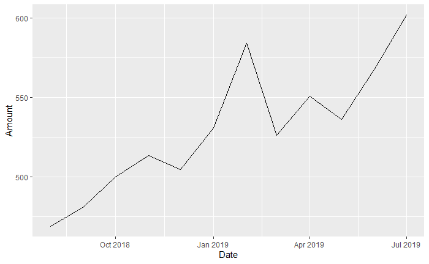

```r
monthly_sales %>%
  filter(Cashflow == "Kwikbit Unit 1 Sales") %>%
  ggplot() +
  geom_line(aes(x = Date, y = Amount))
```

#### Q3:

#### Make a line chart showing monthly revenue and costs over the last year. This data is also in qb_monthly_sales.

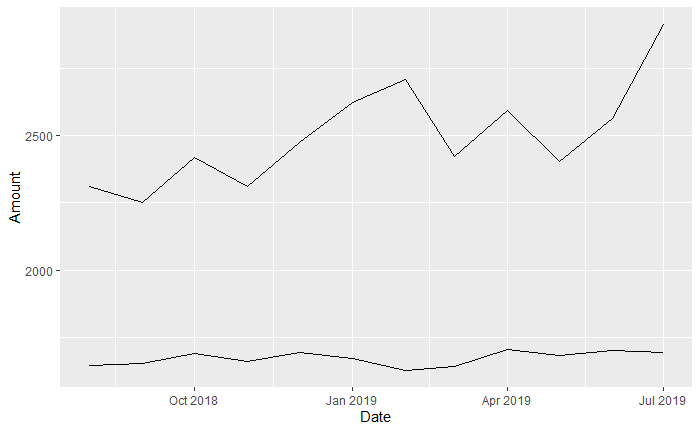

```r
monthly_sales %>%
  filter(Cashflow != "Kwikbit Unit 1 Sales") %>%
  ggplot() +
  geom_line(aes(x = Date, y = Amount, group = Cashflow))
```

#### Q4:

#### Show annual sales of personal fitness trackers over the last 5 years broken down by company as a ribbon plot (use geom_area). This data is in qb_competitors.

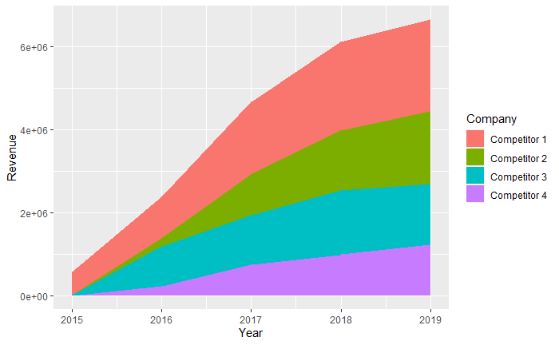

```r
competitors %>%
  ggplot() +
  geom_area(aes(x = Year, y = Revenue, fill = Company))
```

#### Q5:

#### Now show the sales from the four competitors as a line graph. Include an extra layer that shows the data points used to make the lines.

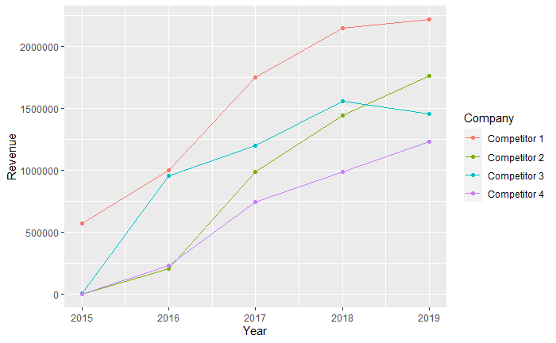

```r
competitors %>%
  ggplot() +
  geom_line(aes(x = Year, y = Revenue, group = Company, colour = Company)) +
  geom_point(aes(x = Year, y = Revenue, colour = Company))
```

#### Q6:

#### Now the company wants to compare the number of steps that their device counts vs. their competitors. Make a line graph of the number of steps throughout time, and use faceting to compare between companies and people. The data for this is in qb_device_data.

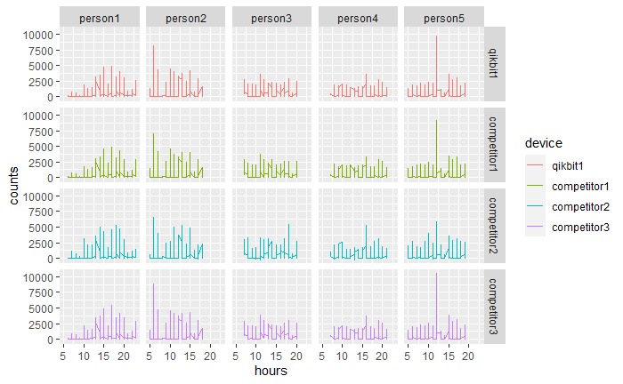

```r
device_data %>%
  ggplot() +
  geom_line(aes(x = hours, y = counts, group = id, colour = device), stat = "identity") +
  facet_grid(device ~ id )
```

```r
NA
NA
```

## Part 2:

I will copy the same base code used in Part 1

#### Q1: Sources of Revenue against Year

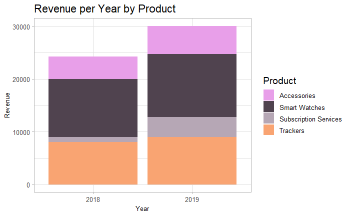

```r
col_scheme <- c("#E89FE9", "#50434F", "#B6A7B5", "#F9A472", "#BD7040")

revenue_breakdown %>%
  ggplot() +
  geom_bar(aes(x = Year, y = Revenue, fill = Product), stat = "identity") +
  ggtitle("Revenue per Year by Product") +
  theme_light(base_size = 12) +
  scale_fill_manual(values = col_scheme) +
  theme(axis.title = element_text(size = 10)) +
  theme(title = element_text(size = 14))
```

#### Q2: Monthly Sales of KwikBit

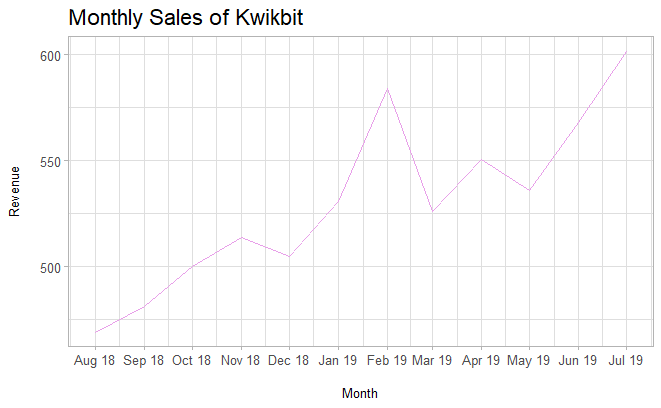

```r
monthly_sales %>%
  filter(Cashflow == "Kwikbit Unit 1 Sales") %>%
  ggplot() +
  geom_line(aes(x = Date,
                y = Amount),
            colour = "#E89FE9") +
  xlab("\nMonth") +
  ylab("Revenue\n") +
  scale_x_date(breaks = "1 month", date_labels = "%b %y") +
  ggtitle("Monthly Sales of Kwikbit") +
  theme_light(base_size = 12) +
  theme(axis.title = element_text(size = 10)) +
  theme(title = element_text(size = 14))
```

#### Q3: Monthly Revenue vs Costs

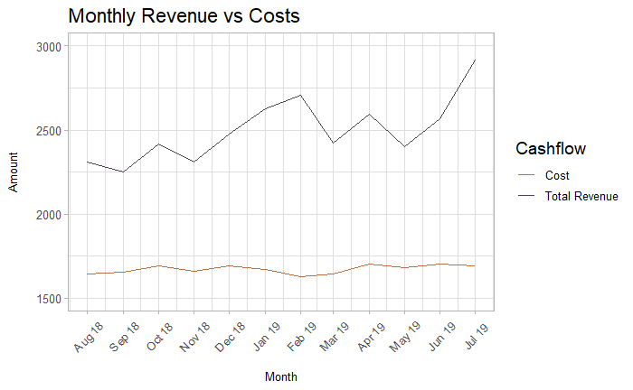

```r
monthly_sales %>%
  filter(Cashflow != "Kwikbit Unit 1 Sales") %>%
  ggplot() +
  geom_line(aes(x = Date, y = Amount, group = Cashflow, colour = Cashflow), position = "dodge") +
  scale_colour_manual(values = c("#BD7040","#50434F")) +
  xlab("\nMonth") +
  ylab("Amount\n") +
  scale_x_date(breaks = "1 month", date_labels = "%b %y") +
  scale_y_continuous(
    breaks = c(1500, 2000, 2500, 3000),
    limits = c(1500, 3000)) +
  ggtitle("Monthly Revenue vs Costs") +
  theme_light(base_size = 12) +
  theme(axis.title = element_text(size = 10)) +
  theme(title = element_text(size = 14)) +
  theme(axis.text.x = element_text(angle = 45, vjust = 0.5))
```

```r
NA
NA
NA
```

#### Q4 : Annual Sales by Company

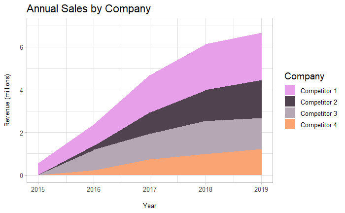

```r
competitors %>%
  mutate(sales_millions = Revenue / 1000000) %>%
  ggplot() +
  geom_area(aes(x = Year, y = sales_millions, fill = Company)) +
  scale_fill_manual(values = col_scheme) +
  xlab("\nYear") +
  ylab("Revenue (millions)\n") +
  scale_y_continuous(labels = scales::comma, limits = c(0,7)) +
  ggtitle("Annual Sales by Company") +
  theme_light(base_size = 12) +
  theme(axis.title = element_text(size = 10)) +
  theme(title = element_text(size = 14))
```

```r
NA
```

#### Q5 : Annual Sales by Company

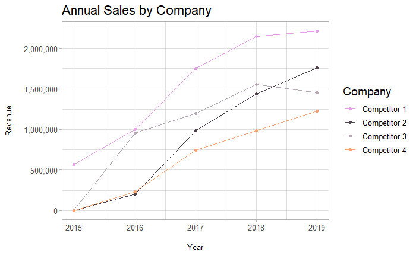

```r
competitors %>%
  ggplot() +
  geom_line(aes(x = Year, y = Revenue, group = Company, colour = Company)) +
  geom_point(aes(x = Year, y = Revenue, colour = Company)) +
  scale_colour_manual(values = col_scheme) +
  xlab("\nYear") +
  ylab("Revenue\n") +
  scale_y_continuous(labels = scales::comma) +
  ggtitle("Annual Sales by Company") +
  theme_light(base_size = 12) +
  theme(axis.title = element_text(size = 10)) +
  theme(title = element_text(size = 14))
```

#### Q6: Step Count per Competitor and Person

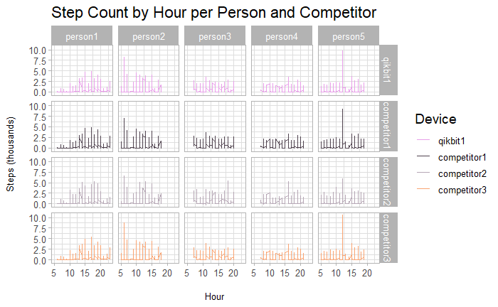

```r
device_data %>%
  mutate(count_thousands = counts / 1000) %>%
  ggplot() +
  geom_line(aes(x = hours, y = count_thousands, group = id, colour = device), stat = "identity") +
  scale_colour_manual(values = col_scheme) +
  facet_grid(device ~ id ) +
  xlab("\nHour") +
  ylab("Steps (thousands)\n") +
  ggtitle("Step Count by Hour per Person and Competitor") +
  labs(colour = "Device") +
  theme_light(base_size = 12) +
  theme(axis.title = element_text(size = 10)) +
  theme(title = element_text(size = 14))
```

```r
NA
```